# Genome Variation analysis

Muthulakshmi Muthuswami

01 February, 2022

# 1 Introduction

This workshop introduces a simple workflow to analyze genomic variations using whole exome sequencing data.

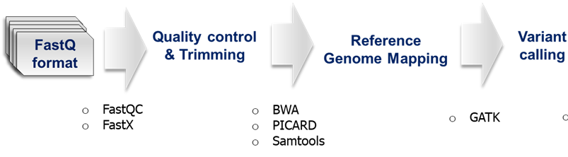

Various steps include

- Test Data overview & download
- Software Installation
- Quality Control and trimming
- Mapping to a reference genome
- Variant calling

Read paper carefully before starting : https://bio-protocol.org/bio101/e2805

# 2 Test data overview & Data download

Test data involves exome sequencing data from [affected individual](https://www.coriell.org/0/Sections/Search/Sample_Detail.aspx?Ref=NA12878&Product=DNA) . The source DNA, known as NA12878, was taken from a single person: the daughter in a father-mother-child ‘trio’ (she is also mother to 11 children of her own). Father-mother-child ‘trios’ are often sequenced to utilize genetic links between family members.

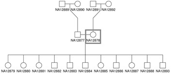

The data we are going to use in this tutorial is uploaded in teams. You can download the data and place it in the local folder of your desktop. The data folder downloaded from teams will have 3 files, 1) the reference.fasta file (genome/hg38_chr10.fa), 2 & 3) the raw data of NA12878 in FASTQ format [NA12878-NGv3-LAB1360-A_1.fastq.gz & NA12878-NGv3-LAB1360-A_2.fastq.gz]. To save time, the fastq information for only one chromosome is uploaded. Hence its not the complete data, it contains only chromosome 10 information. While starting the docker session use –volume tag to access test data inside the docker container. You can try making additional folders as per the need inside the container. It will be automatically refreshed with new files in the local folder also.

bash

```bash
docker run --volume <local_folder>:<remote_folder> --interactive --tty zifornd/bioinfo:latest
```

# 3 Software installation

Create a new conda environment called SNP_NGS and install all the required softwares

bash

```bash
## Update the basic packages of linux.
apt-get update
apt-get install locales

conda create --yes --name SNP_NGS python fastqc fastx_toolkit multiqc snpeff bcftools samtools bwa pip gatk4 picard
```

Activate the environment and check whether the tools are installed.

bash

```bash
conda activate SNP_NGS
```

# 4 Quality Control and trimming

The first thing to do when you receive data is to check its quality. In this step the quality of the raw sequencing data is evaluated and trimmed for better data quality.

## 4.1 Data quality check (FastQC)

FastQC is a program that generates general statistics from high throughput data (and pipelines). As mentioned in your previous lectures, it creates a HTML report. Since we have two FASTQ files, it is convenient to merge all the reports and stats files. We can achieve this by using MultiQC.

bash

```bash
# Check the quality of data using FASTQC.
fastqc  -o  .  NA12878-NGv3-LAB1360-A_1.fastq.gz
fastqc  -o  .  NA12878-NGv3-LAB1360-A_2.fastq.gz
# make a separate directory
mkdir FASTQC_results

# Move the fastqc results to that folder
mv -t FASTQC_results/ NA12878-NGv3-LAB1360-A_1_fastqc.zip NA12878-NGv3-LAB1360-A_2_fastqc.html NA12878-NGv3-LAB1360-A_1_fastqc.html NA12878-NGv3-LAB1360-A_2_fastqc.zip

## Naviate to the FASTQC_results folder and perform multiqc
cd FASTQC_results
## Merge FASTQ files using MultiQC
multiqc .
```

Open multiqc_report.html in webbrowser. As we have used only one chromosome information, you can check how the report looks like.

**Q1. How does the sequencing quality look like? Inspect the different statistics. Would you do any trimming on this data**

## 4.2 QC trimming (FastX)

There are several protocols to follow in order to leave only good quality reads and it is recommended to perform this step even when the data looks fine. FastX is a collection of command line tools that pre-process FASTA/FASTQ files. We can generate graphs, remove adapters, trim based on quality, etc. In the following command, we will first filter the reads based on quality scores and then we will trim bad quality nucleotides from the end of the read. After this trimming, sequences that are shorter than the minimum length will be discarded:

bash

```bash
## Navigate into data folder and perform QC trimming using FastX toolkit

gunzip -c NA12878-NGv3-LAB1360-A_1.fastq.gz | fastq_quality_filter -q20 -p80 -Q33 -v | fastq_quality_trimmer -t10 -l40 -Q33 -v -o NA12878-NGv3-LAB1360-A_1.fastq.trim

gunzip -c NA12878-NGv3-LAB1360-A_2.fastq.gz | fastq_quality_filter -q20 -p80 -Q33 -v | fastq_quality_trimmer -t10 -l40 -Q33 -v -o NA12878-NGv3-LAB1360-A_2.fastq.trim
```

Try to understand the command line, the following information can help you: -Q 33 indicates that the quality is as in the Sanger FASTQ format -q is the minimum quality score to keep -p is the minimum percent of bases that must have -q -t quality threshold, nts with lower quality will be trimmed from the end of the seq -l minimum length of the read

After any kind of trimming it is important to generate QC plots for comparison purposes:

bash

```bash
fastqc  -o  .  NA12878-NGv3-LAB1360-A_1.fastq.trim
fastqc  -o  .  NA12878-NGv3-LAB1360-A_2.fastq.trim

## mv FASTQC results to different folder
mkdir FASTQC_after_trimming

mv -t FASTQC_after_trimming/ NA12878-NGv3-LAB1360-A_2.fastq.trim_fastqc.html NA12878-NGv3-LAB1360-A_2.fastq.trim_fastqc.zip NA12878-NGv3-LAB1360-A_1.fastq.trim_fastqc.html NA12878-NGv3-LAB1360-A_1.fastq.trim_fastqc.zip

#navigate to FASTQC_after_trimming folder and do multiqc
cd FASTQC_after_trimming
multiqc .
cd ..
```

**Q2. Is there any improvement on the data quality after filtering? How many sequences were removed? What other trimming strategies would be suitable for any sequencing data?**

# 5 Mapping to reference genome (BWA, Picard)

Now that we have a good dataset, we will map the reads to our reference genome. Remember that there are several aligners and depending on which one you use you may have slightly different results.

Here we will use BWA, an aligner based on the Burrows-Wheeler transform that has been optimized for aligning short reads.

-p option give the index name (you can call this whatever you want, we named it gch38bwaidx) -a option chooses one of the indexing algorithm within bwa.

bash

```bash
bwa index -p gch38bwaidx -a bwtsw  genome/hg38_chr10.fa

mv -t genome/ gch38*

bwa mem genome/gch38bwaidx NA12878-NGv3-LAB1360-A_1.fastq.trim NA12878-NGv3-LAB1360-A_2.fastq.trim > NA12878.sam
```

The alignment we get is in SAM format. For further handling we need to compress it, so we need to generate an alignment in BAM format (the binary format of SAM). For this, we can use tools like samtools and Picard. Both are a set of command line tools for manipulating high throughput sequencing data:

bash

```bash
## Use samtools sort and convert SAM file to bamfile

samtools view -b NA12878.sam > NA12878.bam
samtools sort NA12878.bam > NA12878_sorted.bam
```

Now we will fix some values in the alignment that are necessary for downstream analysis. Since several samples can be analyzed at the same time, we need to specify platform, sample and library used:

bash

```bash
picard AddOrReplaceReadGroups I= NA12878_sorted.bam O= NA12878.sort.bam SO=coordinate RGID= NA12878 RGLB= NA12878 RGPL=Illumina RGPU= NA12878 RGSM= NA12878
```

**Q3. Here we are assigning values at random. What would be more suitable values for the different flags? You can learn what every flag means [here](https://broadinstitute.github.io/picard/command-line-overview.html#AddOrReplaceReadGroups)**

Finally, we index the BAM file, so other tools have quick access to it:

bash

```bash
picard BuildBamIndex I=NA12878.sort.bam
```

## 5.1 PCR Duplicates (Picard)

When dealing with variant calling, an important step is to identify possible PCR duplicates, this to remove any bias when we are doing the actual calling, for this we can also use Picard tools:

bash

```bash
picard MarkDuplicates I=NA12878.sort.bam O=NA12878.sort.mkdup.bam M=NA12878.metrics

picard BuildBamIndex I=NA12878.sort.mkdup.bam
```

## 5.2 Mapping statistics (samtools)

bash

```bash
samtools flagstat NA12878.sort.mkdup.bam > NA12878.sort.mkdup.flagstat

samtools idxstats NA12878.sort.mkdup.bam > NA12878.sort.mkdup.idxstats
```

**Q4. Have all the reads been mapped to our reference genome? Which chromosome has more coverage? How many duplicates are there in each sample?**

**Q5. Can you try to convert NA12878.sort.mkdup.bam to NA12878.sort.mkdup.cram and its associated index file?**

# 6 Variant Calling

The Genome Analysis Toolkit or GATK is a software package developed to analyze next-generation resequencing data, focusing on variant discovery and genotyping. For the variant calling we will use the HaplotypeCaller, which is an SNP/indel caller that uses a Bayesian genotype likelihood model to estimate simultaneously the most likely genotypes and allele frequency in a population of N samples:

bash

```bash
samtools faidx genome/hg38_chr10.fa

gatk CreateSequenceDictionary -R genome/hg38_chr10.fa -O genome/hg38_chr10.dict

gatk HaplotypeCaller -R genome/hg38_chr10.fa -I NA12878.sort.mkdup.bam -O NA12878.gatk.raw.vcf  --max-alternate-alleles 1
```

**Inspect NA12878.gatk.raw.vcf, get familiar with its information.**

SNP-callers emit a number of false-positive mutations, as any prediction program. Some of these false-positives can be detected and rejected by various statistical tests. Filtering or flagging the variant calls in the vcf file is a useful step to detect such false-positives. For this we will use Variant Filtration from GATK:

bash

```bash
gatk VariantFiltration -R genome/hg38_chr10.fa -V NA12878.gatk.raw.vcf -O NA12878.gatk.raw.flag.vcf -filter "DP < 10.0" --filter-name "LowDP" -filter "QD < 2.0" --filter-name "QD" -filter "MQ < 40.0" --filter-name "MQD" -filter "FS > 60.0" --filter-name "FSsnp" -filter "FS > 200.0" --filter-name "FSindel"
```

Try to understand the filtering done above. You may find some info at the beginning of the vcf file. Now, have a look at NA12878.gatk.raw.flag.vcf.

**Q6. How many variants have passed our filtering criteria?**

Opitonally you can load NA12878.gatk.raw.flag.vcf in IGV and try visualizing the homozygous/heterozygous mutant regions